```python
import numpy as np
import pandas as pd
import seaborn as sns
import matplotlib.pyplot as plt
import statistics
%matplotlib inline
ig = pd.read_csv('/Users/raychilds/Downloads/MFIG4.csv')
```

# Top 40 Followed Instagram Influencers of 2018 (& What It Means)

## I've chosen a dataset provided by Data.World. It contains the Top 40 Most Followed Instagram Influencers, their categories both general and specific, number of followers in millions, age, and nationality. The dataset omits business instagram accounts (Victoria's Secret, Nike, etc), and only explores the personalities. Something to note, these numbers themselves are subject to change at any time due to the nature of the social media world (fluctuating followers, especially in times of celebrity drama/promotion), but this would not necessarily change the influencers themselves, for reasons we'll explore below.

# Meet the Influencers:

# 1) Are There Any Major Patterns in the Top 40?

```
Text(0.5,0,'Top 40 Influencers on Instagram')
```

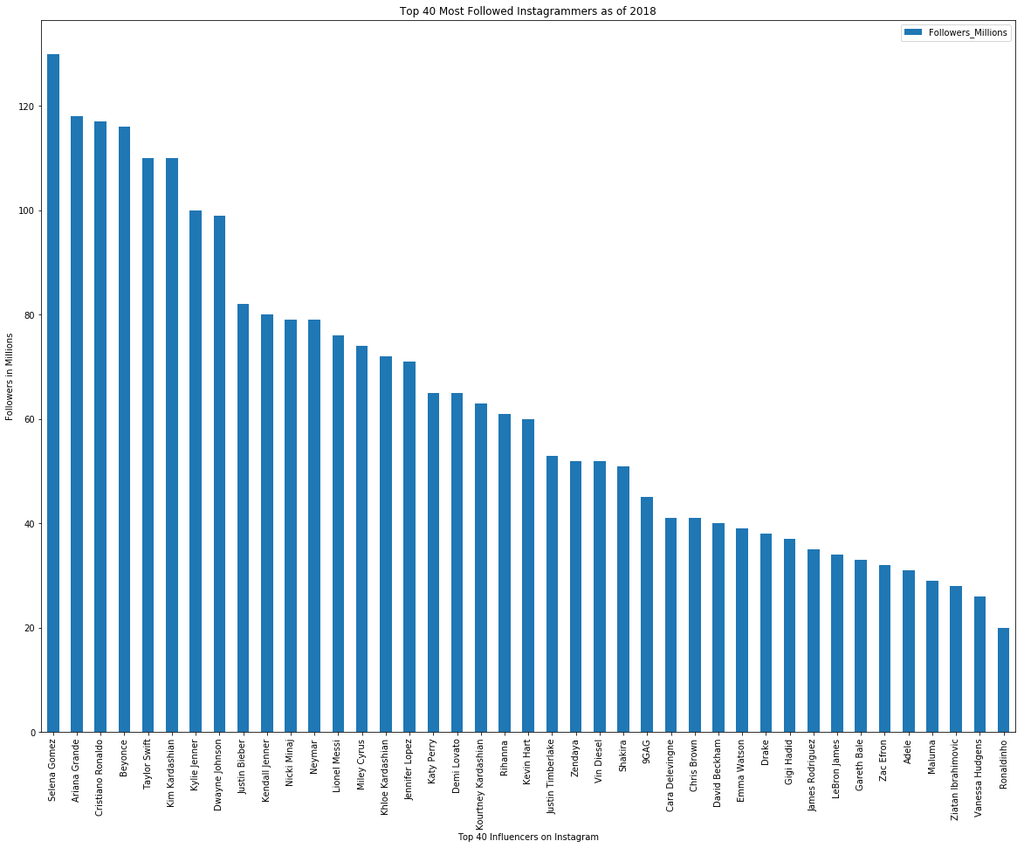

```python
ig.plot(kind='bar', x='brand',y= 'Followers_Millions', title= 'Top 40 Most Followed Instagrammers as of 2018', figsize=(20,15))
plt.ylabel('Followers in Millions')
plt.xlabel('Top 40 Influencers on Instagram')
```

# Here's a snapshot of our Top 8, for those of us who were around for MySpace.

1. Selena Gomez
2. Ariana Grande
3. Cristiano Ronaldo
4. Beyonce
5. Taylor Swift
6. Kim Kardashian
7. Kylie Jenner
8. Dwayne "The Rock" Johnson </center>

## Upon closer examination (but not too close!), it occurred to me that three figureheads in the dataset have had sexual content of theirs posted publically: Kim Kardashian, Justin Bieber, and Vanessa Hudgens. Vanessa Hudgens is an interesting person to be on the Top 40 list in the first place, as she is arguably the least "famous" (i.e. her material is the least advertised and she makes the fewest monetary amount per paid post especially relative to Bieber and Kim); it makes one wonder if the nude leaks, in the end, helped peak/peek interest in these three.

## On that note, I'm compelled to look again, this time getting right down to the roots. There is exactly one (natural) blonde on our 'grammers list! Taylor, that's all you, girl! This gives us a little insight into beauty standards of the decade.

# 2) Demographics of Influencers: Are Instagram Audiences Drawn to One Demographic Over Another?

```
Gender of Top 40 Most Followed Instagram Influencers of 2018
```

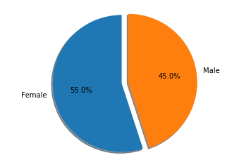

```python
labels = 'Female', 'Male'
sizes = [55, 45]
explode = (0.1, 0)
fig1, ax1 = plt.subplots()
ax1.pie(sizes, explode=explode, labels=labels, autopct='%1.1f%%',
        shadow=True, startangle=90)
ax1.axis('equal')
print("Gender of Top 40 Most Followed Instagram Influencers of 2018")
plt.show()
```

## Females make up 10% more of the Top 40 than males.

```python
ig = pd.read_csv('/Users/raychilds/Downloads/MFIG2.csv')
ig.describe()
```

|  | Followers (Millions) | Age |
| --- | --- | --- |
| count | 41.000000 | 41.000000 |
| mean | 63.024390 | 32.024390 |
| std | 30.096917 | 7.329692 |
| min | 20.000000 | 21.000000 |
| 25% | 38.000000 | 26.000000 |
| 50% | 60.000000 | 31.000000 |
| 75% | 79.000000 | 37.000000 |
| max | 130.000000 | 51.000000 |

```python
statistics.mode(ig['Age'])
```

```
26
```

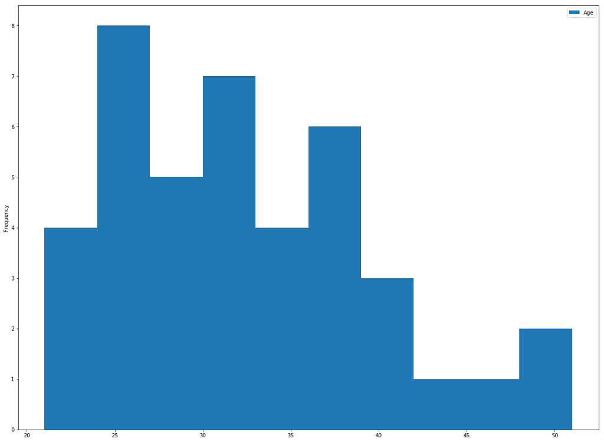

```python
ig.plot(kind='hist', x='brand',y= 'Age', figsize=(20,15))
```

## The youngest influencer is 21 years old, Ms. Kylie Jenner.

## Could it be that certain ages have any more or less followers than the others in the list? Let's check it out:

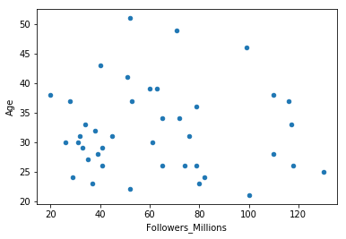

```python
ig.plot(kind='scatter', x='Followers_Millions',y= 'Age')
```

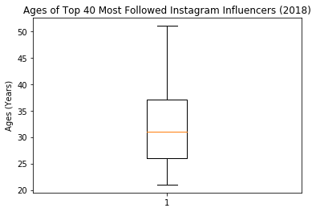

```python
x = ig['Age']
plt.title('Ages of Top 40 Most Followed Instagram Influencers (2018)')
plt.ylabel('Ages (Years)')
plt.boxplot(x)
plt.show()
```

## So, now that we've established from when they're from, how about from where?

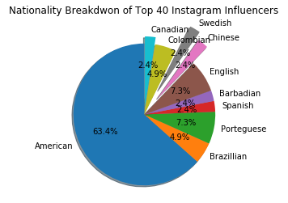

```python
labels = 'American', 'Brazillian', 'Porteguese' , 'Spanish', 'Barbadian', 'English', 'Chinese', 'Swedish','Colombian', 'Canadian'
sizes = [26, 2, 3, 1, 1, 3, 1, 1, 2, 1]
fig1, ax1 = plt.subplots()
explode = (0, 0, 0, 0, 0, 0, 0.3, 0.4, 0, 0.1)
ax1.pie(sizes,labels=labels, explode=explode, autopct='%1.1f%%',
        shadow=True, startangle=90)
ax1.axis('equal')
plt.title("Nationality Breakdwon of Top 40 Instagram Influencers")
plt.show()
```

## Nationality is a difficult greyscale topic. For example, Nicki Minaj is Trinidadian, but she spent most of her childhood and life in New York City. Also, most of the influencers now live in the United States and have dual citizenship, but they are counted here as their country of origin.

## Americans make up 63.4% of the Top 40 Most Followed. The Latino community is not far behind, with almost 20% of the makeup, 10% out of Brazil and Colombia. Keep this in mind as we explore professions below. If you are a Top 40 pop music listener, this may not come as too much of a surprise for you. There is an uptick in blending hip hop, electronic, and most recently the Latino music industries. Pop dance music can be cheaply electronically produced, so bass (Latin or African in root) is a defining feature of the genres.

# 3) What Cultural Values are Represented in the Data?

```
Text(0.5,1,'Industry of Top 40 Instagram Influencers')
```

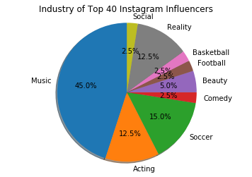

```python
labels = 'Music', 'Acting', 'Soccer', 'Comedy', 'Beauty', 'Football', 'Basketball', 'Reality','Social'
sizes = [18, 5, 6, 1, 2, 1, 1, 5, 1]
fig1, ax1 = plt.subplots()
explode = (0, 0, 0, 0, 0, 0, 0, 0, 0,)
ax1.pie(sizes,labels=labels, explode=explode, autopct='%1.1f%%',
        shadow=True, startangle=90)
ax1.axis('equal')
plt.title("Industry of Top 40 Instagram Influencers")
```

## Be sure not to neglect the littliest slices of the pie! Even though, say, football is only 2.5% of the overall influencers, they still made the cut over all other sports (or any category for that matter). Remember our figure from earlier - 12.5% of the entire set is composed of all five of the Kardashian sisters. No other influencer makes up this stat; this means 100% of the Reality Celebrity profession is from one single family!

## Soccer by itself deserves it's own blurb. 15% of the Top 40 Most Followed Instagram influencers are soccer players! These players are the majority of the Latino community we just checked out, saving for Maluma and Shakira, who are musicians.

## It's important to note most influencers play multiple roles in this multi-faceted decade. Think about musicians, for example. Back some 40 years ago, profits came predominantly from long awaited albums. With the genesis of the internet, however; most if not all of the Age of Technology has been spent fighting pirating. Napster, Limewire...etc. Lo and behold, streaming saved the day. Pirating was sharply cut back, but not without some trade-off. Revenue was cut greatly, so what's a musician to do? As a musician in the 21st century, you have to be a jack of all trades. Model, actor, instagrammer, fashion designer, perfume and makeup entreprenuers, marketeers...you name it. So, let's see what that looks like. Combine beauty, musicians, actors, reality, and social:

```
Influencer Brands in the Top 40
```

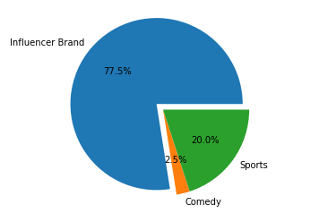

```python
labels = 'Influencer Brand', 'Comedy', 'Sports'
sizes = [77.5, 2.5, 20]
explode = (0.1, 0, 0)
fig1, ax1 = plt.subplots()
ax1.pie(sizes, explode=explode, labels=labels, autopct='%1.1f%%')
ax1.axis('equal')
print("Influencer Brands in the Top 40")
plt.show()
```

## CHECK THAT OUT! Over 3/4's of our influencers live as "New Age Renaissance Men", if you will. If our parameters were paid promotion of any media, however, our pie turns whole!

# Conclusion

## It seems to me if you have certain qualities, a perfect storm of looks and a capacity to appeal to the masses (or hire someone to do so), you're well on your way to owning a sizable portion of new wealth. Something we haven't covered here? Moo-la. Here's a factoid to blow your socks off. Ms. Kylie Jenner (our youngest instagrammer) makes one million dollars PER paid instragram post. It pays to post, ladies and gentlemen (at least if you're a Kardashian or Disney affiliate!) Would Kylie be such a rockstar if she weren't born into the already world-famous family? Chances are very, very slim. However, we do see it is possible to become famous by your own accord, as Justin Bieber started as an independent musician on YouTube. Human beings are explorers, and, seeing as we've pretty much covered exploration of land masses - the new frontier is indeed online and there certainly is a vast audience to see who will do what, next.

# Further Exploration

## It is no secret the United States of America plays a huge cultural role in the world, with hotly debated topics including exceptionalism, capitalism, and cultural imperialism. While exploring the data, I struggled to categorize the influencers in terms of black and white, for example, American vs. Barbadian. Is Rihanna an American influencer as she now works and lives in the United States as this is where the industry is? Can we count her as a Barbadian influencer? If ethnicity had been brought into the puzzle, perhaps all of this data could be considered skewed. To be "American" even, is a very difficult topic. What is American? Is it citizenship? It is in this particular data that we see how important the multicultural melting pot is to the American world.

## Something else that occurred to me as I explored this dataset: race. Continuing on my piece above on ethnicity and nationality and "Americanism"...how much of the influencers identify as African American or mixed race? And, perhaps more importantly, how has this changed over the years? We are burdened with the limited timeline of social media, Instagram only being around for 10 years! Perhaps other means could be used to account for the top influencers of the 20th century, and how they compare to now. It will also be interesting to continue to watch the cultural infusion as the years go by.

### *Fun Fact: The sum of their followers is 2,584,682,964 users.

### WHAT?! How could this astronomical number be real? Think about it this way, what are the odds that one user only follows one of these influencers and none of the other? Pretty small. This is the sum total of followers, but, say, you love to watch Taylor Swift and Kim Kardashian's feuding...you'd be counted twice at the very least by these means.